# Exponential Smoothing

Jeremy O'Brien & Juliann McEachern  
17 September 2019

*Prepared for Data 622 - Predictive Analytics*

## Agenda

- Simple Exponential Smoothing
- Trend Methods
- Seasonal Methods
- Classification of Methods
- State Space Models (ETS)
- ETS Estimatation & Model Selection
- Forcasting with ETS

### Simple Exponential Smoothing

### Simple Methods

- Want something in between that weights most recent data more highly.
- Simple exponential smoothing uses a weighted moving average with weights that decrease exponentially.

Time series: \( y_1,y_2,\dots,y_T \).

Random walk forecast: \[ \begin{aligned} \hat{y}{T+h}{T} = y_T$ \end{aligned} \]

Average forecast: \[ \begin{aligned} \hat{y}{T+h}{T} = \frac1T\sum_{t=1}^T y_t \end{aligned} \]

### Forecast equation

\[ \begin{aligned} \hat{y}{T+1}{T} = \alpha y_T + \alpha(1-\alpha) y_{T-1} + \alpha(1-\alpha)^2 y_{T-2}+ \cdots \end{aligned} \\ \text{where} 0 \le \alpha \le1$ \]

### Component form

Iterate to get exponentially weighted moving average form.

\[ \begin{align*} \text{Forecast equation}&&\hat{y}{t+h}{t} &= \ell_{t}\\ \text{Smoothing equation}&&\ell_{t} &= \alpha y_{t} + (1 - \alpha)\ell_{t-1} \end{align*} \]

- \( \ell_t \) is the level (or the smoothed value) of the series at time t.
- \( \hat{y}{t+1}{t} = \alpha y_t + (1-\alpha) \hat{y}{t}{t-1} \)

### Weighted average form

\[ \begin{align*} \displaystyle\hat{y}{T+1}{T}=\sum_{j=0}^{T-1} \alpha(1-\alpha)^j y_{T-j}+(1-\alpha)^T \ell_{0} \end{align*} \]

### Optimization

- Need to choose value for \( \alpha \) and \( \ell_0 \)
- Similarly to regression — we choose \( \alpha \) and \( \ell_0 \) by minimising SSE: \[ \begin{aligned} \text{SSE}=\sum_{t=1}^T(y_t - \hat{y}{t}{t-1})^2. \end{aligned} \]
- Unlike regression there is no closed form solution — use numerical optimization.

### Example: Oil production

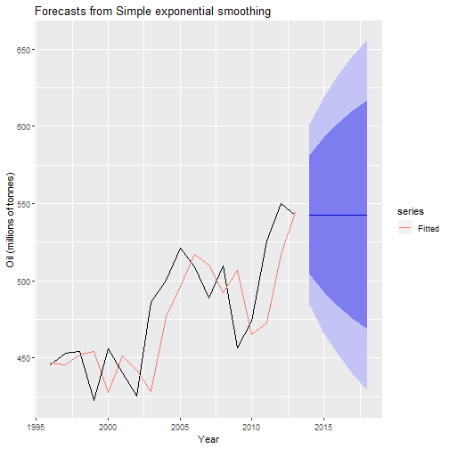

```r
oildata <- window(oil, start=1996)
# Estimate parameters
fc <- ses(oildata, h=5)
autoplot(fc) +
  autolayer(fitted(fc), series="Fitted") +
  ylab("Oil (millions of tonnes)") + xlab("Year")
```

### Trend Methods

### Holt's linear trend

Component form \[ \begin{align*} \text{Forecast }&& \hat{y}{t+h}{t} &= \ell_{t} + hb_{t} \\ \text{Level }&& \ell_{t} &= \alpha y_{t} + (1 - \alpha)(\ell_{t-1} + b_{t-1})\\ \text{Trend }&& b_{t} &= \beta^*(\ell_{t} - \ell_{t-1}) + (1 -\beta^*)b_{t-1}, \end{align*} \]

### Holt's method in R

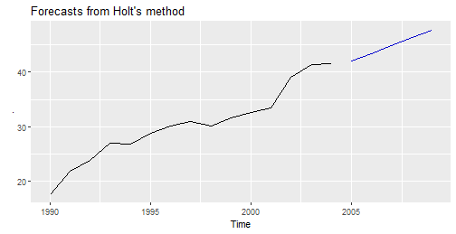

```r
window(ausair, start=1990, end=2004) %>%
  holt(h=5, PI=FALSE) %>%
  autoplot()
```

### Damped trend method

Component form \[ \begin{align*} \hat{y}{t+h}{t} &= \ell_{t} + (\phi+\phi^2 + \dots + \phi^{h})b_{t} \\ \ell_{t} &= \alpha y_{t} + (1 - \alpha)(\ell_{t-1} + \phi b_{t-1})\\ b_{t} &= \beta^*(\ell_{t} - \ell_{t-1}) + (1 -\beta^*)\phi b_{t-1}. \end{align*} \]

- Damping parameter \( 0<\phi<1 \).
- If $ \phi=1$, identical to Holt's linear trend.
- As $ h\rightarrow\infty$, $ \hat{y}{T+h}{T}\rightarrow \ell_T+\phi b_T/(1-\phi)$.
- Short-run forecasts trended, long-run forecasts constant.

### Example: Air passengers

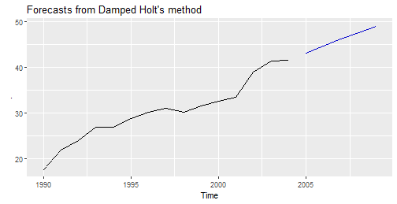

```r
window(ausair, start=1990, end=2004) %>%
  holt(damped=TRUE, h=5, PI=FALSE) %>%
  autoplot()
```

### Seasonal Methods

### Holt-Winters additive method

Holt and Winters extended Holt's method to capture seasonality.

Component form \[ \begin{align*} \hat{y}{t+h}{t} &= \ell_{t} + hb _{t} + s_{t+h-m(k+1)} \\ \ell_{t} &= \alpha(y_{t} - s_{t-m}) + (1 - \alpha)(\ell_{t-1} + b_{t-1})\\ b_{t} &= \beta^*(\ell_{t} - \ell_{t-1}) + (1 - \beta^*)b_{t-1}\\ s_{t} &= \gamma (y_{t}-\ell_{t-1}-b_{t-1}) + (1-\gamma)s_{t-m}, \end{align*} \]

### Holt-Winters multiplicative method

For when seasonal variations are changing proportional to the level of the series.

Component form \[ \begin{align*} \hat{y}{t+h}{t} &= (\ell_{t} + hb_{t})s_{t+h-m(k+1)}. \\ \ell_{t} &= \alpha \frac{y_{t}}{s_{t-m}} + (1 - \alpha)(\ell_{t-1} + b_{t-1})\\ b_{t} &= \beta^*(\ell_{t}-\ell_{t-1}) + (1 - \beta^*)b_{t-1} \\ s_{t} &= \gamma \frac{y_{t}}{(\ell_{t-1} + b_{t-1})} + (1 - \gamma)s_{t-m} \end{align*} \]

- $ k$ is integer part of $ (h-1)/m$.
- With additive method $ s_t$ is in absolute terms:\newline within each year $ \sum_i s_i \approx 0$.
- With multiplicative method $ s_t$ is in relative terms:\newline within each year $ \sum_i s_i \approx m$.

### Example: Visitor Nights

```r
aust <- window(austourists,start=2005)
fit1 <- hw(aust,seasonal="additive")
fit2 <- hw(aust,seasonal="multiplicative")
```

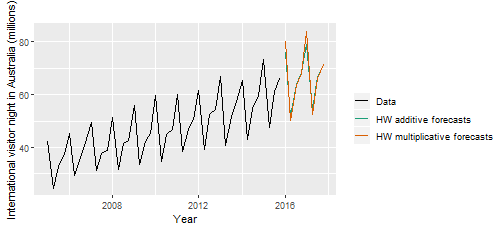

```r
tmp <- cbind(Data=aust,
  "HW additive forecasts" = fit1[["mean"]],
  "HW multiplicative forecasts" = fit2[["mean"]])

autoplot(tmp) + xlab("Year") +
  ylab("International visitor night in Australia (millions)") +
  scale_color_manual(name="",
    values=c('#000000','#1b9e77','#d95f02'),
    breaks=c("Data","HW additive forecasts","HW multiplicative forecasts"))
```

### Example: Vistor nights estimated components

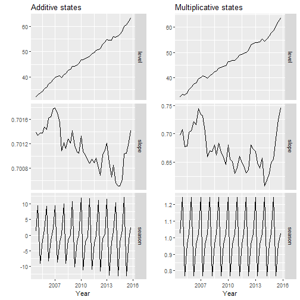

```r
addstates <- fit1$model$states[,1:3]
multstates <- fit2$model$states[,1:3]
colnames(addstates) <- colnames(multstates) <-
  c("level","slope","season")
p1 <- autoplot(addstates, facets=TRUE) + xlab("Year") +
  ylab("") + ggtitle("Additive states")
p2 <- autoplot(multstates, facets=TRUE) + xlab("Year") +
  ylab("") + ggtitle("Multiplicative states")
gridExtra::grid.arrange(p1,p2,ncol=2)
```

### Holt-Winters damped method

Often the single most accurate forecasting method for seasonal data: \[ \begin{align*} \hat{y}{t+h}{t} &= [\ell_{t} + (\phi+\phi^2 + \dots + \phi^{h})b_{t}]s_{t+h-m(k+1)} \\ \ell_{t} &= \alpha(y_{t} / s_{t-m}) + (1 - \alpha)(\ell_{t-1} + \phi b_{t-1})\\ b_{t} &= \beta^*(\ell_{t} - \ell_{t-1}) + (1 - \beta^*)\phi b_{t-1} \\ s_{t} &= \gamma \frac{y_{t}}{(\ell_{t-1} + \phi b_{t-1})} + (1 - \gamma)s_{t-m} \end{align*} \]

### Classification of Methods

### State Space Models (ETS)

### ETS Estimatation & Model Selection